[figure not shown]

```r
options(scipen = 999)

library(tidyverse)
library(tidycensus)
library(urbnthemes)
library(reactable)
library(readxl)

set_urbn_defaults()
```

# County Population

```r
# https://www2.census.gov/geo/pdfs/maps-data/maps/reference/us_regdiv.pdf
regions <-
  tribble(
    ~state_fips, ~state, ~region,
    "01", "Alabama", "South",
    "02", "Alaska", "West",
    "04", "Arizona", "West",
    "05", "Arkansas", "South",
    "06", "California", "West",
    "08", "Colorado", "West",
    "09", "Connecticut", "Northeast",
    "10", "Delaware", "South",
    "11", "District of Columbia", "South",
    "12", "Florida", "South",
    "13", "Georgia", "South",
    "15", "Hawaii", "West",
    "16", "Idaho", "West",
    "17", "Illinois", "Midwest",
    "18", "Indiana", "Midwest",
    "19", "Iowa", "Midwest",
    "20", "Kansas", "Midwest",
    "21", "Kentucky", "South",
    "22", "Louisiana", "South",
    "23", "Maine", "Norsttheast",
    "24", "Maryland", "South",
    "25", "Massachusetts", "Northeast",
    "26", "Michigan", "Midwest",
    "27", "Minnesota", "Midwest",
    "28", "Mississippi", "South",
    "29", "Missouri", "Midwest",
    "30", "Montana", "West",
    "31", "Nebraska", "Midwest",
    "32", "Nevada", "West",
    "33", "New Hampshire", "Northeast",
    "34", "New Jersey", "Northeast",
    "35", "New Mexico", "West",
    "36", "New York", "Northeast",
    "37", "North Carolina", "South",
    "38", "North Dakota", "Midwest",
    "39", "Ohio", "Midwest",
    "40", "Oklahoma", "South",
    "41", "Oregon", "West",
    "42", "Pennsylvania", "Northeast",
    "44", "Rhode Island", "Northeast",
    "45", "South Carolina", "South",
    "46", "South Dakota",  "Midwest",
    "47", "Tennessee", "South",
    "48", "Texas", "South",
    "49", "Utah", "West",
    "50", "Vermont", "Northeast",
    "51", "Virginia", "South",
    "53", "Washington", "West",
    "54", "West Virginia", "South",
    "55", "Wisconsin", "Midwest",
    "56", "Wyoming", "West"
  )
```

```r
population <-
  get_estimates(geography = "county", product = "population", year = 2019, output = "wide") %>%
  rename_all(tolower)
```

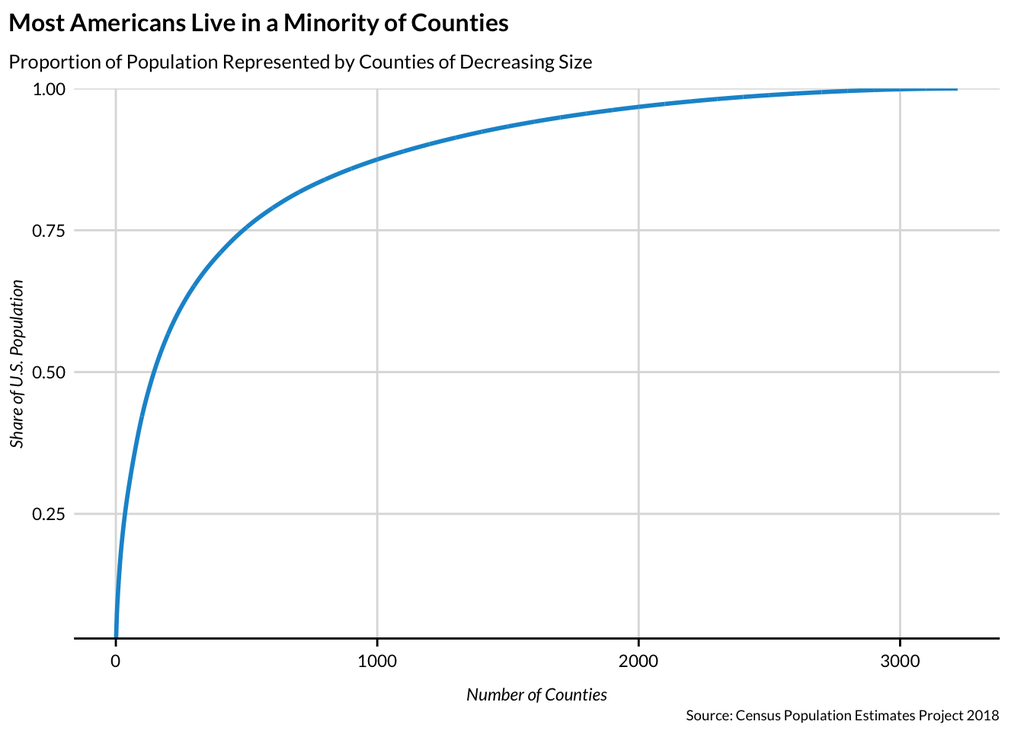

```r
population %>%
  arrange(desc(pop)) %>%
  mutate(`Number of Counties` = row_number(),
         `Share of U.S. Population` = cumsum(pop) / sum(pop)) %>%
  ggplot(aes(`Number of Counties`, `Share of U.S. Population`)) +
  geom_line() +
  scale_y_continuous(expand = c(0, 0)) +
  labs(title = "Most Americans Live in a Minority of Counties",
       subtitle = "Proportion of Population Represented by Counties of Decreasing Size",
       caption = "Source: Census Population Estimates Project 2018") +
  scatter_grid()
```

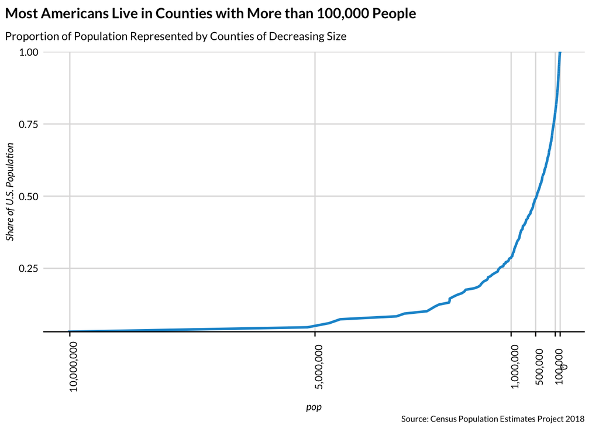

```r
population %>%
  arrange(desc(pop)) %>%
  mutate(`Number of Counties` = row_number(),
         `Share of U.S. Population` = cumsum(pop) / sum(pop)) %>%
  ggplot(aes(pop, `Share of U.S. Population`)) +
  geom_line() +
  scale_x_reverse(breaks = c(0, 100000, 500000, 1000000, 5000000, 10000000),
                  labels = scales::comma) +
  scale_y_continuous(expand = c(0, 0)) +
  scatter_grid() +
  labs(title = "Most Americans Live in Counties with More than 100,000 People",
       subtitle = "Proportion of Population Represented by Counties of Decreasing Size",
       caption = "Source: Census Population Estimates Project 2018") +
  theme(axis.text.x = element_text(angle = 90))
```

# Demographics

```r
vars <- tribble(
  ~variable, ~var_name,
  "B01003_001", "population",
  "B01001B_001", "black",
  "B01001H_001", "non_hispanic_white",
  "B01001I_001", "hispanic_or_latino",
  "B06012_002", "poverty",
  # median household income
  "B19013_001", "med_hh_income",
  "B19301_001", "pc_income",
  "DP02_0092P", "foreign_born",
  "B01002_001", "median_age",
  "DP02_0064P", "ed_ba",
  "DP02_0065P", "ed_ma"
)

acs2018 <- get_acs(geography = "county",
                   variables  = vars$variable,
                   year = 2018,
                   geometry = FALSE,
                   progress = FALSE)

acs2018 <- left_join(acs2018, vars, by = "variable") %>%
  select(geoid = GEOID,
         name = NAME,
         estimate,
         var_name) %>%
  pivot_wider(names_from = var_name,
              values_from = estimate)

acs2018 <- acs2018 %>%
  mutate(poverty = poverty / population) %>%
  mutate(
    ed_ba_plus = (ed_ba + ed_ma) / 100,
    foreign_born = foreign_born / 100,
    black = black / population,
    non_hispanic_white = non_hispanic_white / population,
    hispanic_or_latino = hispanic_or_latino / population
  ) %>%
  select(-ed_ba, -ed_ma)

# filter to counties of interest
fips <- read_excel(here::here("10_construct-database", "RFI Applicant List w. Codes.xlsx")) %>%
  pull(`FIPS Code`)

fips <- as.character(flatten(str_split(fips, "; "))) %>%
  str_pad(width = 5, pad = "0")

combined_data <- left_join(population, acs2018, by = "geoid") %>%
  filter(geoid %in% fips) %>%
  mutate(state = str_sub(geoid, start = 1, end = 2),
         county = str_sub(geoid, start = 3, end = 5)) %>%
  select(state,
         county,
         name = name.x,
         population,
         density,
         black,
         non_hispanic_white,
         hispanic_or_latino,
         foreign_born,
         poverty,
         med_hh_income,
         pc_income,
         ed_ba_plus) %>%
  filter(state != "72")

combined_data %>%
  left_join(regions, by = c("state" = "state_fips")) %>%
  count(region)

write_csv(combined_data, here::here("10_construct-database", "applicant-demographics.csv"))
```

[output not shown]

- `population` Number of people in the county
- `density` Number of people per square mile in the county
- `black` Proportion of the population that is black, (Hispanic and non-Hispanic)
- `non_hispanic_white` Proportion of the population that is white, non-Hispanic
- `hispanic_or_latino` Proportion of the population that is Hispanic or Latino
- `foreign_born` Proportion of the population that is foreign born
- `poverty` Proportion of the population living below the poverty level
- `med_hh_income` Median household income in the county
- `pc_income` Average per capita income in the county
- `ed_ba_plus`Proportion of the population ages 25+ with a BA degree or higher

**Scroll right to see more variables**

```r
combined_data %>%
  reactable(
    columns = list(
      density = colDef(format = colFormat(digits = 1)),
      non_hispanic_white = colDef(format = colFormat(digits = 2)),
      black = colDef(format = colFormat(digits = 2)),
      hispanic_or_latino = colDef(format = colFormat(digits = 2)),
      foreign_born = colDef(format = colFormat(digits = 2)),
      poverty = colDef(format = colFormat(digits = 2))
    ),
    filterable = TRUE,
    searchable = TRUE,
    defaultPageSize = 20,
    highlight = TRUE
  )
```

| state | county | name | population | density | black | non_hispanic_white | hispanic_or_latino | foreign_born | poverty | med_hh_income | pc_income | ed_ba_plus |
| --- | --- | --- | --- | --- | --- | --- | --- | --- | --- | --- | --- | --- |
| 21 | 111 | Jefferson County, Kentucky | 767154 | 2014.0227305 | 0.214670066244848 | 0.679312106826009 | 0.0522932814011268 | 0.074 | 0.144569408489039 | 54357 | 31980 | 0.328 |
| 27 | 053 | Hennepin County, Minnesota | 1235478 | 2285.5562907 | 0.130500097937802 | 0.69163028398725 | 0.0690129650224447 | 0.141 | 0.108275501465829 | 74113 | 43976 | 0.493 |
| 27 | 109 | Olmsted County, Minnesota | 153065 | 242.17997944 | 0.0592166726554078 | 0.805533596837945 | 0.0483585404893346 | 0.109 | 0.088132492731846 | 74880 | 39667 | 0.44 |
| 42 | 003 | Allegheny County, Pennsylvania | 1225561 | 1665.5479101 | 0.128831612624749 | 0.78762542215361 | 0.0203376249733795 | 0.057 | 0.118184243787131 | 58383 | 36907 | 0.407 |
| 29 | 019 | Boone County, Missouri | 176515 | 263.23792216 | 0.0878338951363907 | 0.790034841231623 | 0.0337081834405008 | 0.066 | 0.173396028666119 | 54043 | 29365 | 0.46 |
| 48 | 201 | Harris County, Texas | 4602523 | 2762.5492191 | 0.190188511822755 | 0.300711587970337 | 0.425628073993329 | 0.261 | 0.160585835203865 | 60146 | 31901 | 0.31 |
| 48 | 113 | Dallas County, Texas | 2586552 | 3021.0825913 | 0.225071059851107 | 0.29607601161701 | 0.399373374283602 | 0.243 | 0.163885744419598 | 56854 | 31219 | 0.307 |
| 50 | 013 | Grand Isle County, Vermont | 6965 | 88.438827029 | 0.00789662598707825 | 0.929361091170136 | 0.0190954773869347 | 0.042 | 0.0758076094759512 | 69583 | 40464 | 0.392 |
| 50 | 011 | Franklin County, Vermont | 49025 | 77.906075915 | 0.00595614482406935 | 0.939316675165732 | 0.0151351351351351 | 0.028 | 0.0762876083630801 | 64258 | 30692 | 0.237 |
| 50 | 025 | Windham County, Vermont | 43150 | 53.751162248 | 0.0117960602549247 | 0.932375434530707 | 0.0227578215527231 | 0.035 | 0.129177288528389 | 52659 | 31563 | 0.386 |

[output cut: 60 more lines]

# File Quality

The following table describes the quality of the data for the communities of interest. There are 30 metrics because some of the metrics contain multiple variables. For example, the race-ethnicity exposure metrics have variables for white non-Hispanic, Black non-Hispanic, and Hispanic. Most variables for most communities have “Good” quality.

```r
metrics <- read_csv(here::here("10_construct-database", "mobility-metrics.csv"))

metrics <- metrics %>%
  mutate(geoid = paste0(state, county)) %>%
  filter(geoid %in% fips)

metrics_quality <- metrics %>%
  select(county_name, state_name, ends_with("_quality")) %>%
  pivot_longer(cols = -c(state_name, county_name)) %>%
  group_by(state_name, county_name) %>%
  summarize(quality_good = sum(value == 1, na.rm = TRUE),
            quality_marginal = sum(value == 2, na.rm = TRUE),
            quality_poor = sum(value == 3, na.rm = TRUE),
            missing_values = sum(is.na(value)))

metrics_quality %>%
  reactable(
    # columns = list(
    #   density = colDef(format = colFormat(digits = 1)),
    #   non_hispanic_white = colDef(format = colFormat(digits = 2)),
    #   black = colDef(format = colFormat(digits = 2)),
    #   hispanic_or_latino = colDef(format = colFormat(digits = 2)),
    #   foreign_born = colDef(format = colFormat(digits = 2)),
    #   poverty = colDef(format = colFormat(digits = 2))
    # ),
    filterable = TRUE,
    searchable = TRUE,
    defaultPageSize = 20,
    highlight = TRUE
  )
```

| state_name | county_name | quality_good | quality_marginal | quality_poor | missing_values |
| --- | --- | --- | --- | --- | --- |
| California | Alameda County | 23 | 2 | 5 | 0 |
| California | Los Angeles County | 22 | 3 | 5 | 0 |
| California | Marin County | 21 | 4 | 5 | 0 |
| California | Riverside County | 23 | 2 | 5 | 0 |
| California | San Bernardino County | 22 | 3 | 5 | 0 |
| California | Sonoma County | 23 | 2 | 5 | 0 |
| California | Yolo County | 24 | 2 | 4 | 0 |
| Colorado | Adams County | 23 | 1 | 6 | 0 |
| Colorado | Larimer County | 22 | 2 | 6 | 0 |
| District of Columbia | District of Columbia | 24 | 1 | 1 | 4 |

[output cut: 60 more lines]

```r
write_csv(metrics_quality, here::here("10_construct-database", "mobility-metrics-quality.csv"))
```

This table shows the share of each metric that have “Good” quality.

```r
metrics %>%
  select(ends_with("_quality")) %>%
  pivot_longer(cols = everything()) %>%
  mutate(value = if_else(is.na(value), 0, value)) %>%
  group_by(name) %>%
  summarize(share_good = mean(value == 1)) %>%
  reactable(
    columns = list(
      share_good = colDef(format = colFormat(digits = 3))
    ),
    filterable = TRUE,
    searchable = TRUE,
    defaultPageSize = 20,
    highlight = TRUE
  )
```

| name | share_good |
| --- | --- |
| asian_other_quality | 0 |
| black_nh_exposure_quality | 1 |
| black_nonhispanic_quality | 0 |
| crime_rate_quality | 0.428571428571429 |
| election_turnout_quality | 1 |
| employed_quality | 0.842857142857143 |
| famstruc_quality | 0.842857142857143 |
| frpl40_black_quality | 0.814285714285714 |
| frpl40_hispanic_quality | 0.828571428571429 |
| frpl40_total_quality | 0.842857142857143 |

[output cut: 20 more lines]